# Script 3 - Impacts on individual physiology

Blood parasites and avian health

Marie Buysse, Mathilde Ollagnier, Charly Souc, Marjorie Bruley, Thomas Blanchon, Carole Leray, Marion Vittecoq and Karen D. McCoy

# 0.Librairies

```r
library(readxl) #read_excel function
library(ggplot2)
library(dplyr)
library(kableExtra) #kable function
library(ggpubr) #ggarrange function
library(lme4) #lmer function
library(MuMIn) #dredge function
library(sjPlot) #tab_model function
library(DHARMa) #simulateResiduals function
library(lmtest) #bptest, dwtest functions
```

**Information about data visualisation:**  
For a same variable, one data visualisation is based on fixed effect selected in the best-fitted model and most significant random effects. Another visualisation include the infection status or parasitemia, whether significant or not.

# 1. Data

## 1.1. Data loading

```r
data <- read_excel("Data_Impacts on individual physiology_v2.xlsx")
data$Site <- as.factor(data$Site)
data$Sample <- as.factor(data$Sample)
data$Year <- as.factor(data$Year)
data$Age <- as.factor(data$Age)
data$Status_qPCR <- as.factor(data$Status_qPCR)
data$Ratio_qPCR <- as.numeric(data$Ratio_qPCR)
data$ErrorRatio_qPCR <- as.numeric(data$ErrorRatio_qPCR)
data$Hemoglobin <- as.numeric(data$Hemoglobin)
data$Weight <- as.numeric(data$Weight)
data$Tarsus <- as.numeric(data$Tarsus)
data$RatioWT <- as.numeric(data$RatioWT)
data$Sex <- as.factor(data$Sex)
data$SMI <- as.numeric(data$SMI)
data$Ticks_by_nest <- as.numeric(data$Ticks_by_nest)
```

With:  
-Site: sampling colony (Carteau/Frioul)  
-Sample: ID of individual bird  
-Year: sampling year (2022/2023/2024)  
-Age: age of bird (Chick/Adult)  
-Status_qPCR: infection status based on qPCR technique (uninfected/infected)  
-Ratio_qPCR: quantification of *Babesia* based on qPCR technique (ratio *Larus*/*Babesia* copies of genes)  
-ErrorRatio_qPCR: ratio error associated with `Ratio_qPCR`  
-Hemoglobin: measure of circulating concentration of hemoglobin  
-Tarsus: length of the tarsus  
-Weight: bird weight  
-RatioWT: ratio between `Weight` and `Tarsus`  
-Sex: sex of bird (F/M)  
-SMI: Scaled Mess Index (see Script S1)  
-Ticks_by_nest:number of ticks collected in the nest

## 1.2. Preliminary analyses

### 1.2.1. Metrics about parasitemia

```r
data_parasitemia <- data[!(is.na(data$Ratio_qPCR)), ]
```

```r
summary_table_parasitemia <- data_parasitemia %>%
  group_by(Age) %>%
  summarise(
    Mean = mean(Ratio_qPCR),
    SD = sd(Ratio_qPCR),
    SE = sd(Ratio_qPCR, na.rm = TRUE) / sqrt(length(Ratio_qPCR)),
    N = n())

summary_table_parasitemia %>%
  kable(caption = "Metrics about Ratio_qPCR based on Age") %>%
  kable_styling(bootstrap_options = c("striped", "hover", "condensed", "responsive"))
```

Metrics about Ratio_qPCR based on Age

| Age | Mean | SD | SE | N |
| --- | --- | --- | --- | --- |
| Adult | 0.0000799 | 0.0001558 | 0.0000493 | 10 |
| Chick | 0.0011438 | 0.0031937 | 0.0006387 | 25 |

### 1.2.2. Circulating concentration of hemoglobin

Let’s see first if `Hemoglobin` levels are equivalent between chicks and adults:

```r
a <- data$Hemoglobin[data$Age=="Chick"]
b <- data$Hemoglobin[data$Age=="Adult"]
wilcox.test(a,b, paired=FALSE)
```

```
##
##  Wilcoxon rank sum test with continuity correction
##
## data:  a and b
## W = 528.5, p-value < 2.2e-16
## alternative hypothesis: true location shift is not equal to 0
```

Since p-value is much smaller than 0.05 (< 2.2e-16), the `Hemoglobin` levels significantly differ between chicks and adults.  
**`Hemoglobin` analyses will be conducted on separate datasets based on `Age`.**

```r
data_hemo <- data[!(is.na(data$Hemoglobin)), ]
data_hemo_adults <- filter(data_hemo, Age == "Adult")
data_hemo_chicks <- filter(data_hemo, Age == "Chick")
```

Here are some metrics about `Hemoglobin` for each dataset:

```r
summary_table_1 <- data_hemo %>%
  group_by(Age) %>%
  summarise(
    Mean = mean(Hemoglobin),
    SD = sd(Hemoglobin),
    SE = sd(Hemoglobin, na.rm = TRUE) / sqrt(length(Hemoglobin)),
    N = n(),
    CI_lower = Mean - qt(0.975, df = N - 1) * (SD / sqrt(N)),
    CI_upper = Mean + qt(0.975, df = N - 1) * (SD / sqrt(N))
  )

summary_table_1 %>%
  kable(caption = "Metrics about Hemoglobin based on Age") %>%
  kable_styling(bootstrap_options = c("striped", "hover", "condensed", "responsive"))
```

Metrics about Hemoglobin based on Age

| Age | Mean | SD | SE | N | CI_lower | CI_upper |
| --- | --- | --- | --- | --- | --- | --- |
| Adult | 11.865049 | 1.947382 | 0.1918812 | 103 | 11.484453 | 12.245644 |
| Chick | 8.032653 | 1.032939 | 0.1043426 | 98 | 7.825562 | 8.239744 |

```r
data_hemo_stats <- data_hemo[!(is.na(data_hemo$Status_qPCR)), ]
summary_table_2 <- data_hemo_stats %>%
  group_by(Age, Status_qPCR) %>%
  summarise(
    Mean = mean(Hemoglobin),
    SD = sd(Hemoglobin),
    SE = sd(Hemoglobin, na.rm = TRUE) / sqrt(length(Hemoglobin)),
    N = n(),
    CI_lower = Mean - qt(0.975, df = N - 1) * (SD / sqrt(N)),
    CI_upper = Mean + qt(0.975, df = N - 1) * (SD / sqrt(N))
  )

summary_table_2 %>%
  kable(caption = "Metrics about Hemoglobin based on Age and infection status") %>%
  kable_styling(bootstrap_options = c("striped", "hover", "condensed", "responsive"))
```

Metrics about Hemoglobin based on Age and infection status

| Age | Status_qPCR | Mean | SD | SE | N | CI_lower | CI_upper |
| --- | --- | --- | --- | --- | --- | --- | --- |
| Adult | infected | 11.440000 | 2.0570745 | 0.6505041 | 10 | 9.968457 | 12.911542 |
| Adult | uninfected | 11.910753 | 1.9413388 | 0.2013075 | 93 | 11.510939 | 12.310567 |
| Chick | infected | 7.753125 | 1.1606406 | 0.2051742 | 32 | 7.334669 | 8.171581 |
| Chick | uninfected | 8.215873 | 0.9336378 | 0.1176273 | 63 | 7.980739 | 8.451007 |

### 1.2.2.1. Data distribution of `Hemoglobin` in adults

In the dataset `data_hemo_adults` (excluding missing values of `Status_qPCR`, `Sex` and `Ticks_by_nest` because these variables will be used in our analyses, i.e. `data_hemo_ad_model`):

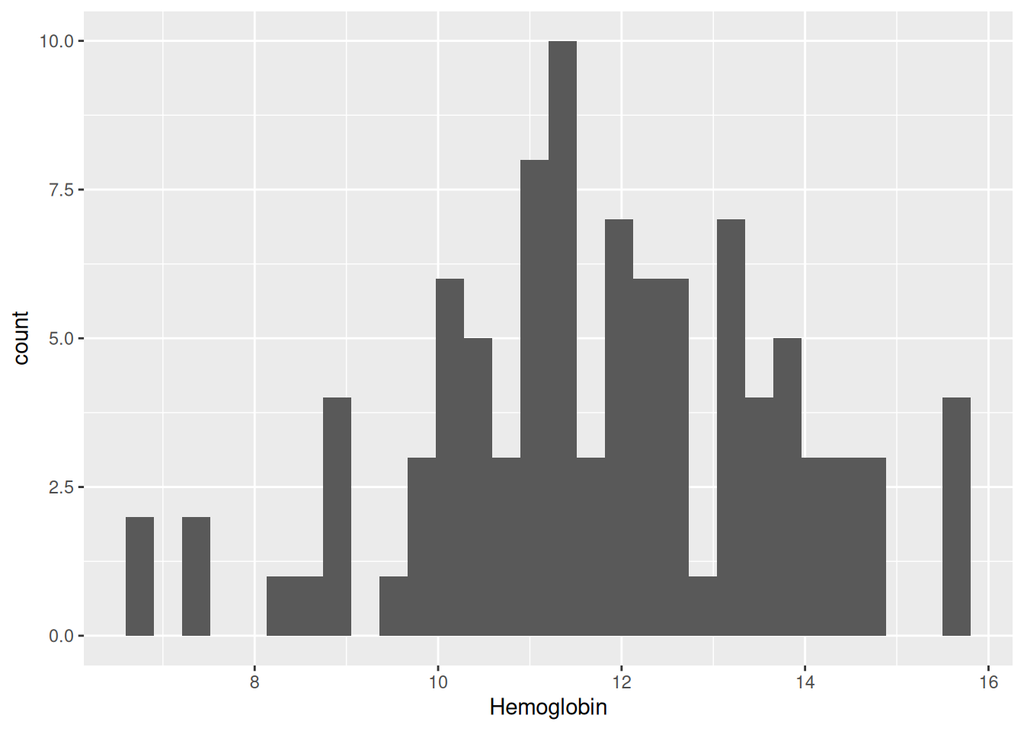

```r
data_hemo_ad_model <- data_hemo_adults %>%
  filter(!is.na(Status_qPCR), !is.na(Sex), , !is.na(Ticks_by_nest))

ggplot(data_hemo_ad_model, aes(x=Hemoglobin)) + geom_histogram()
```

```r
shapiro.test(data_hemo_ad_model$Hemoglobin)
```

```
##
##  Shapiro-Wilk normality test
##
## data:  data_hemo_ad_model$Hemoglobin
## W = 0.98529, p-value = 0.3469
```

Since p-value is greater than 0.05 (p-value = 0.3469), **`data_hemo_ad_model$Hemoblobin` variable is normally distributed**. We will perform the analyses using LMER and check for distribution of model residuals.

In the dataset `data_hemo_adults` with only individuals with `Ratio_qPCR`:

```r
data_hemo_ad_ratioBab <- data_hemo_adults %>%
  filter(!is.na(Ratio_qPCR))
```

Considering that this dataset includes only 10 individuals, **the impact of the parasitemia (`Ratio_qPCR`) on `Hemoglobin` in adults will not be examined by models but rather by simple comparison tests**.

### 1.2.2.2. Data distribution of `Hemoglobin` in chicks

In the dataset `data_hemo_chicks` (excluding missing values of `Status_qPCR`, `Sex` and `Ticks_by_nest` because these variables will be used in our analyses, i.e. `data_hemo_ch_model`):

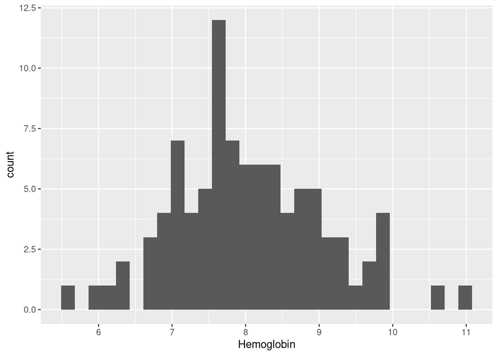

```r
data_hemo_ch_model <- data_hemo_chicks %>%
  filter(!is.na(Status_qPCR), !is.na(Sex), , !is.na(Ticks_by_nest))

ggplot(data_hemo_ch_model, aes(x=Hemoglobin)) + geom_histogram()
```

```r
shapiro.test(data_hemo_ch_model$Hemoglobin)
```

```
##
##  Shapiro-Wilk normality test
##
## data:  data_hemo_ch_model$Hemoglobin
## W = 0.99123, p-value = 0.796
```

Since p-value is greater than 0.05 (p-value = 0.796), **`data_hemo_ch_model$Hemoblobin` variable is normally distributed**. We will perform the analyses using LMER and check for distribution of model residuals.

In the dataset `data_hemo_chicks` with only individuals with `Ratio_qPCR` and `Ticks_by_nest`:

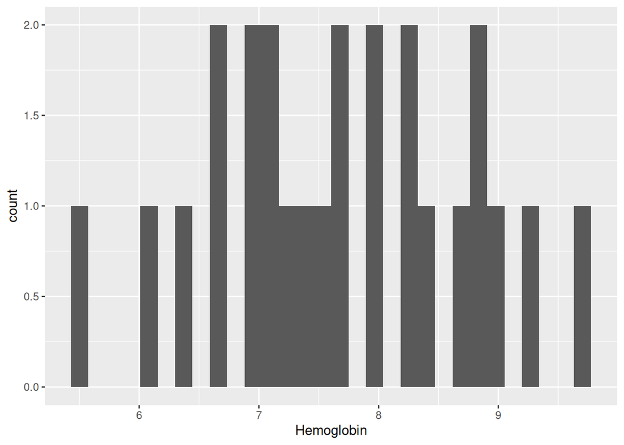

```r
data_hemo_ch_ratioBab <- data_hemo_chicks %>%
  filter(!is.na(Ratio_qPCR), !is.na(Ticks_by_nest))

ggplot(data_hemo_ch_ratioBab, aes(x=Hemoglobin)) + geom_histogram()
```

```r
shapiro.test(data_hemo_ch_ratioBab$Hemoglobin)
```

```
##
##  Shapiro-Wilk normality test
##
## data:  data_hemo_ch_ratioBab$Hemoglobin
## W = 0.98933, p-value = 0.9935
```

Since p-value is greater than 0.05 (p-value = 0.9935), **`data_hemo_ch_ratioBab$Hemoblobin` variable is normally distributed**. We will perform the analyses using LMER and check for distribution of model residuals.

### 1.2.3. Body condition

**Body condition is considered as `SMI`.**

Let’s see first if `SMI` levels are equivalent between chicks and adults:

```r
c <- data$SMI[data$Age=="Chick"]
d <- data$SMI[data$Age=="Adult"]
wilcox.test(c,d, paired=FALSE)
```

```
##
##  Wilcoxon rank sum test with continuity correction
##
## data:  c and d
## W = 232, p-value < 2.2e-16
## alternative hypothesis: true location shift is not equal to 0
```

Since p-value is much smaller than 0.05 (< 2.2e-16), the `SMI` levels significantly differ between chicks and adults.  
**`SMI` analyses will be conducted on separate datasets based on `Age`.**

```r
data_smi <- data[!(is.na(data$SMI)), ]
data_smi_adults <- filter(data_smi, Age == "Adult")
data_smi_chicks <- filter(data_smi, Age == "Chick")
```

```r
summary_table_1 <- data_smi %>%
  group_by(Age) %>%
  summarise(
    Mean = mean(SMI),
    SD = sd(SMI),
    SE = sd(SMI, na.rm = TRUE) / sqrt(length(SMI)),
    N = n(),
    CI_lower = Mean - qt(0.975, df = N - 1) * (SD / sqrt(N)),
    CI_upper = Mean + qt(0.975, df = N - 1) * (SD / sqrt(N))
  )

summary_table_1 %>%
  kable(caption = "Metrics about SMI based on Age") %>%
  kable_styling(bootstrap_options = c("striped", "hover", "condensed", "responsive"))
```

Metrics about SMI based on Age

| Age | Mean | SD | SE | N | CI_lower | CI_upper |
| --- | --- | --- | --- | --- | --- | --- |
| Adult | 1046.0316 | 92.20075 | 9.08481 | 103 | 1028.0119 | 1064.051 |
| Chick | 742.7302 | 105.06756 | 10.66799 | 97 | 721.5544 | 763.906 |

```r
data_smi_stats <- data_smi[!(is.na(data_smi$Status_qPCR)), ]
summary_table_2 <- data_smi_stats %>%
  group_by(Age, Status_qPCR) %>%
  summarise(
    Mean = mean(SMI),
    SD = sd(SMI),
    SE = sd(SMI, na.rm = TRUE) / sqrt(length(SMI)),
    N = n(),
    CI_lower = Mean - qt(0.975, df = N - 1) * (SD / sqrt(N)),
    CI_upper = Mean + qt(0.975, df = N - 1) * (SD / sqrt(N))
  )

summary_table_2 %>%
  kable(caption = "Metrics about SMI based on Age and infection status") %>%
  kable_styling(bootstrap_options = c("striped", "hover", "condensed", "responsive"))
```

Metrics about SMI based on Age and infection status

| Age | Status_qPCR | Mean | SD | SE | N | CI_lower | CI_upper |
| --- | --- | --- | --- | --- | --- | --- | --- |
| Adult | infected | 996.0847 | 42.89468 | 13.564489 | 10 | 965.3997 | 1026.7697 |
| Adult | uninfected | 1051.4022 | 94.57633 | 9.807109 | 93 | 1031.9244 | 1070.8800 |
| Chick | infected | 757.3328 | 117.70384 | 20.807295 | 32 | 714.8961 | 799.7696 |
| Chick | uninfected | 729.4088 | 90.56437 | 11.410038 | 63 | 706.6005 | 752.2171 |

### 1.2.3.1. Data distribution of `SMI` in adults

In the dataset `data_smi_adults` (excluding missing values of `Status_qPCR`, `Sex` and `Ticks_by_nest` because these variables will be used in our analyses, i.e. `data_smi_ad_model`):

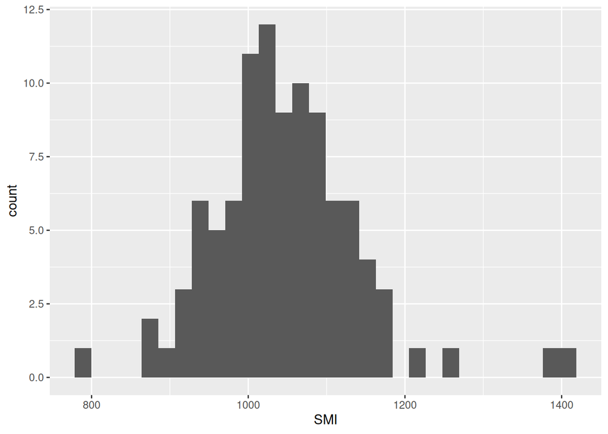

```r
data_smi_ad_model <- data_smi_adults %>%
  filter(!is.na(Status_qPCR), !is.na(Sex), , !is.na(Ticks_by_nest))

ggplot(data_smi_ad_model, aes(x=SMI)) + geom_histogram()
```

```r
shapiro.test(data_smi_ad_model$SMI)
```

```
##
##  Shapiro-Wilk normality test
##
## data:  data_smi_ad_model$SMI
## W = 0.95188, p-value = 0.001266
```

Since p-value is smaller than 0.05 (p-value = 0.001266), **`data_smi_ad_model$SMI` variable is not normally distributed**, but we will perform the analyses using LMER and check for distribution of model residuals.

In the dataset `data_smi_adults` with only individuals with `Ratio_qPCR`:

```r
data_smi_ad_ratioBab <- data_smi_adults[!(is.na(data_smi_adults$Ratio_qPCR)), ]
```

Considering that this dataset includes only 10 individuals, **the impact of the parasitemia (`Ratio_qPCR`) on `SMI` in adults will not be examined by models but rather by simple comparison tests**.

### 1.2.3.2. Data distribution of `SMI` in chicks

In the dataset `data_smi_chicks` (excluding missing values of `Status_qPCR`, `Sex` and `Ticks_by_nest` because these variables will be used in our analyses, i.e. `data_smi_ch_model`):

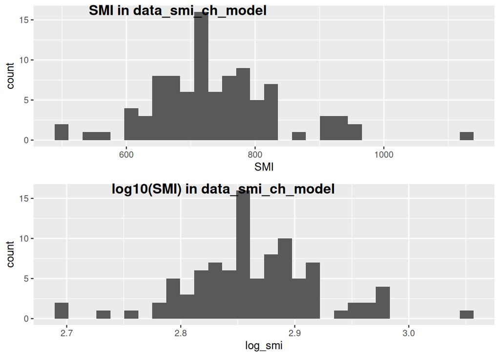

```r
data_smi_ch_model <- data_smi_chicks %>%
  filter(!is.na(Status_qPCR), !is.na(Sex), , !is.na(Ticks_by_nest))

e <- ggplot(data_smi_ch_model, aes(x=SMI)) + geom_histogram()
shap_test1 <- shapiro.test(data_smi_ch_model$SMI)

data_smi_ch_model$log_smi <- log10(data_smi_ch_model$SMI)
f <- ggplot(data_smi_ch_model, aes(x=log_smi)) + geom_histogram()
shap_test2 <- shapiro.test(data_smi_ch_model$log_smi)

ggarrange(e,f, labels = c("SMI in data_smi_ch_model", "log10(SMI) in data_smi_ch_model"), ncol = 1, nrow = 2)
```

```r
shapiro_results_hemo <- data.frame(
  Tests = c("Shapiro test on SMI in chicks", "Shapiro test on log10(SMI) in chicks"),
  p_value = c(shap_test1$p.value, shap_test2$p.value))

shapiro_results_hemo %>%
  kable(caption = "Shapiro test results for SMI in data_smi_ch_model") %>%
  kable_styling(bootstrap_options = c("striped", "hover", "condensed", "responsive"))
```

Shapiro test results for SMI in data_smi_ch_model

| Tests | p_value |
| --- | --- |
| Shapiro test on SMI in chicks | 0.0065251 |
| Shapiro test on log10(SMI) in chicks | 0.0997141 |

Since p-value is greater than 0.05 (p-value = 0.0997141), **`data_smi_ch_model$log_smi` variable is normally distributed**. We will perform the analyses using LMER and check for distribution of model residuals.

In the dataset `data_smi_chicks` with only individuals with `Ratio_qPCR`:

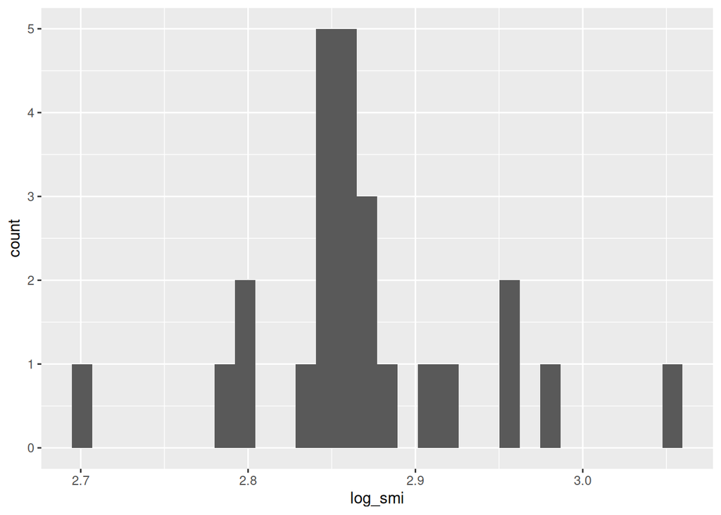

```r
data_smi_ch_ratioBab <- data_smi_chicks %>%
  filter(!is.na(Ratio_qPCR), !is.na(Ticks_by_nest))
data_smi_ch_ratioBab$log_smi <- log10(data_smi_ch_ratioBab$SMI)

ggplot(data_smi_ch_ratioBab, aes(x=log_smi)) + geom_histogram()
```

```r
shapiro.test(data_smi_ch_ratioBab$log_smi)
```

```
##
##  Shapiro-Wilk normality test
##
## data:  data_smi_ch_ratioBab$log_smi
## W = 0.92509, p-value = 0.067
```

Since p-value is greater than 0.05 (p-value = 0.067), **`data_smi_ch_ratioBab$log_smi` variable is normally distributed**. We will perform the analyses using LMER and check for distribution of model residuals.

# 2. Effects of infection on circulating concentration of hemoglobin

## 2.1. Based on infectious status (binary: infected/uninfected)

### 2.1.1. In adults

We include the variables `Status_qPCR`, `Ticks_by_nest` and `SMI` as fixed effects and `Site`, `Sex`, and `Year` as random effects in our full LMER model:

```r
lmer_hemo_ad_full <- lmer(Hemoglobin ~ Status_qPCR * SMI * Ticks_by_nest + (1|Site) + (1|Sex) + (1|Year), data=data_hemo_ad_model, na.action = na.fail)
```

We use the dredge function to compare models:

```r
model_dredge_hemo_ad <- dredge(lmer_hemo_ad_full)
model_dredge_hemo_ad
```

```
## Global model call: lmer(formula = Hemoglobin ~ Status_qPCR * SMI * Ticks_by_nest +
##     (1 | Site) + (1 | Sex) + (1 | Year), data = data_hemo_ad_model,
##     na.action = na.fail)
## ---
## Model selection table
##     (Int)       SMI Stt_qPC Tck_by_nst SMI:Stt_qPC SMI:Tck_by_nst
## 1   11.91
## 3   11.92                 +
## 2   16.72 -0.004590
## 5   11.77                      0.01843
## 4   16.63 -0.004726       +
## 7   11.74                 +    0.01841
## 39  10.46                 +    0.10940
## 6   16.79 -0.004818            0.02221
## 8   16.67 -0.005005       +    0.02291
```

[output cut: 33 more lines]

Based on `model_dredge_hemo_ad`, the model with the minimal AICc value is `1 + (1|Site) + (1|Sex) + (1|Year)`.  
To validate it as the best-fitted model, we compare it with all models having an AICc difference of 2 or less:

```r
lmer_hemo_ad_1 <- lmer(Hemoglobin ~ 1 + (1|Site) + (1|Sex) + (1|Year), data=data_hemo_ad_model, na.action = na.fail)
lmer_hemo_ad_2 <- lmer(Hemoglobin ~ Status_qPCR + (1|Site) + (1|Sex) + (1|Year), data=data_hemo_ad_model, na.action = na.fail)

anova1 <- anova(lmer_hemo_ad_1, lmer_hemo_ad_2, test="Chisq")

p_value_anova1 <- anova1$`Pr(>Chisq)`[2]

anova_results_hemo_ad <- data.frame(
  Comparison = c("null (best)",
                 "best vs Status_qPCR"),
  ANOVA_p_value = c("-", p_value_anova1),
  AICc = c(AICc(lmer_hemo_ad_1), AICc(lmer_hemo_ad_2)))

# Print the table with kable
anova_results_hemo_ad %>%
  kable(caption = "Results of comparison between best AICc model and other models") %>%
  kable_styling(bootstrap_options = c("striped", "hover", "condensed", "responsive"))
```

Results of comparison between best AICc model and other models

Comparison

ANOVA_p_value

AICc

null (best)

407.2099

best vs Status_qPCR

0.973126204058362

408.5483

We can also compare them with `tab_model` function:

```r
tab_model(lmer_hemo_ad_1, lmer_hemo_ad_2, string.est = "IRR", show.aicc = TRUE, digits=2, show.ci = FALSE, show.intercept = FALSE)
```

|  | Hemoglobin |  | Hemoglobin |  |
| --- | --- | --- | --- | --- |
| Predictors | IRR | p | IRR | p |
| Status qPCR [uninfected] |  |  | -0.01 | 0.987 |
| Random Effects |  |  |  |  |
| σ<sup>2</sup> | 3.13 |  | 3.16 |  |
| τ<sub>00</sub> | 0.14 <sub>Year</sub> |  | 0.14 <sub>Year</sub> |  |
|  | 1.13 <sub>Sex</sub> |  | 1.13 <sub>Sex</sub> |  |
|  | 0.21 <sub>Site</sub> |  | 0.21 <sub>Site</sub> |  |
| ICC | 0.32 |  | 0.32 |  |
| N | 2 <sub>Site</sub> |  | 2 <sub>Site</sub> |  |
|  | 2 <sub>Sex</sub> |  | 2 <sub>Sex</sub> |  |
|  | 3 <sub>Year</sub> |  | 3 <sub>Year</sub> |  |
| Observations | 98 |  | 98 |  |
| Marginal R<sup>2</sup> / Conditional R<sup>2</sup> | 0.000 / 0.320 |  | 0.000 / 0.318 |  |
| AICc | 407.210 |  | 408.548 |  |

Based on these results, we select `1 + (1|Site) + (1|Sex) + (1|Year)` as the best-fitted model.

We examine the best-fitted model:

```r
summary(lmer_hemo_ad_1)
```

```
## Linear mixed model fit by REML ['lmerMod']
## Formula: Hemoglobin ~ 1 + (1 | Site) + (1 | Sex) + (1 | Year)
##    Data: data_hemo_ad_model
##
## REML criterion at convergence: 396.6
##
## Scaled residuals:
##      Min       1Q   Median       3Q      Max
## -2.55371 -0.50310  0.06279  0.71228  1.65275
##
## Random effects:
##  Groups   Name        Variance Std.Dev.
##  Year     (Intercept) 0.1365   0.3694
##  Sex      (Intercept) 1.1301   1.0631
##  Site     (Intercept) 0.2057   0.4535
##  Residual             3.1273   1.7684
## Number of obs: 98, groups:  Year, 3; Sex, 2; Site, 2
##
## Fixed effects:
##             Estimate Std. Error t value
## (Intercept)  11.9144     0.8637   13.79
```

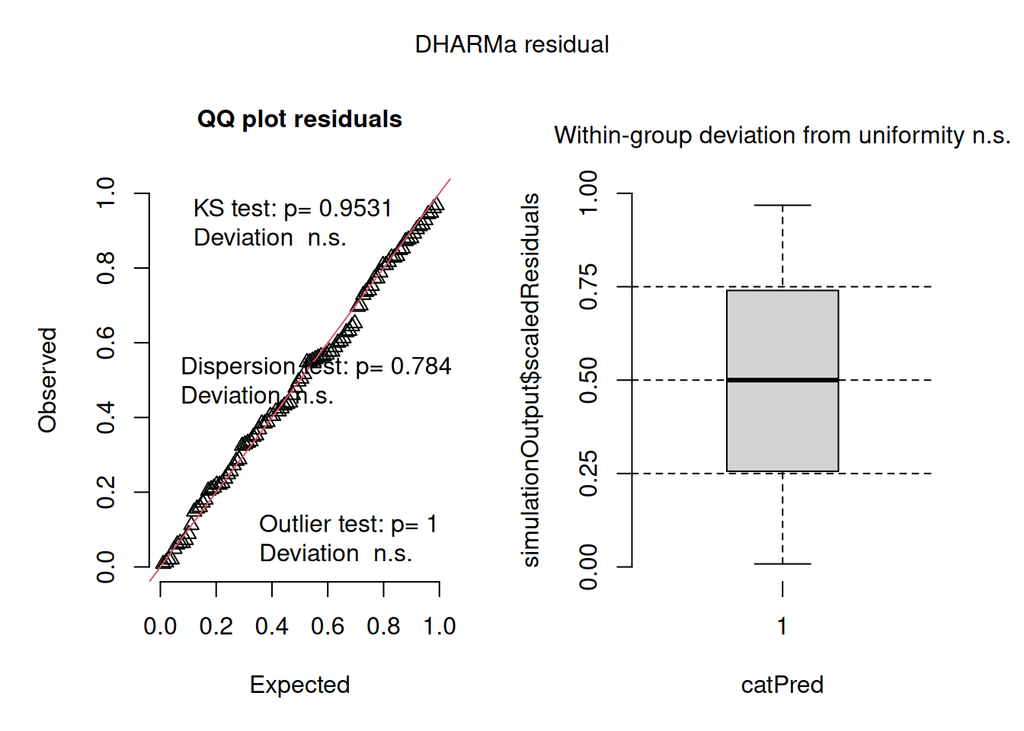

```r
simulationOutput_hemo_ad <- simulateResiduals(fittedModel = lmer_hemo_ad_1, plot = F)
plot(simulationOutput_hemo_ad)
```

```r
shapiro.test(residuals(lmer_hemo_ad_1))
```

```
##
##  Shapiro-Wilk normality test
##
## data:  residuals(lmer_hemo_ad_1)
## W = 0.97026, p-value = 0.02539
```

**None of the examined variables are fixed effects influencing the circulating concentration of hemoglobin in adults, so the presence of *Babesia* does not appear to have any impact.**

Visualisation:

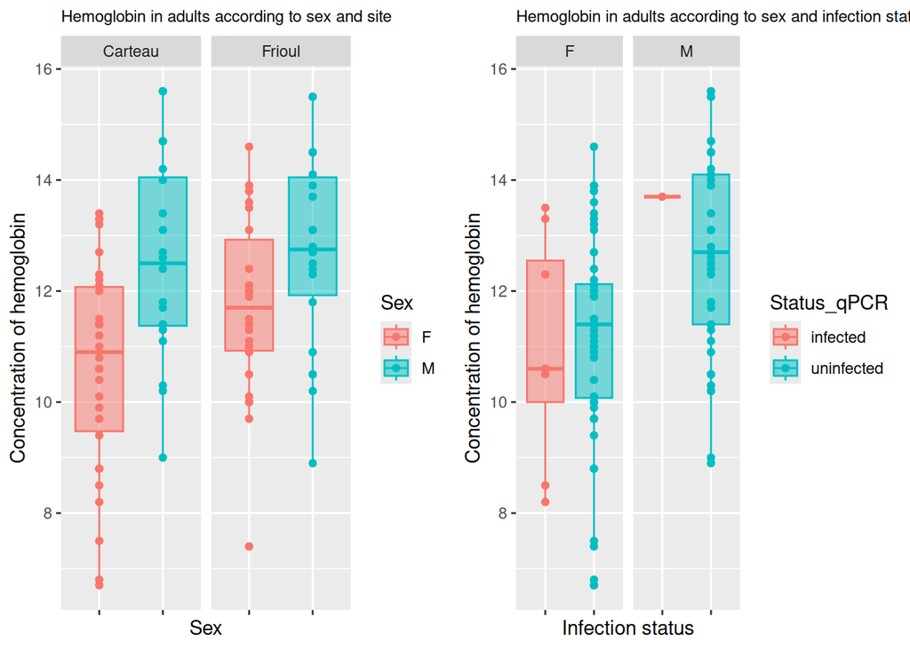

```r
plotA <- ggplot(data_hemo_ad_model, aes(x= Sex, y= Hemoglobin, color=Sex, fill=Sex))+
  geom_point() +
  geom_boxplot(alpha=0.5) +
  labs(x = "Sex",
       y = "Concentration of hemoglobin",
       title = "Hemoglobin in adults according to sex and site") +
  theme(axis.text.x = element_blank(),
        plot.title = element_text(size = 9)) +
  facet_grid(~Site)

plotB <- ggplot(data_hemo_ad_model, aes(x= Status_qPCR, y= Hemoglobin, color=Status_qPCR, fill=Status_qPCR))+
  geom_point() +
  geom_boxplot(alpha= 0.5) +
  labs(x = "Infection status",
       y = "Concentration of hemoglobin",
       title = "Hemoglobin in adults according to sex and infection status")+
  theme(plot.title = element_text(size = 9),
        axis.text.x = element_blank()) +
  facet_grid(~Sex)

ggarrange(plotA, plotB, nrow = 1, ncol = 2)
```

### 2.1.2. In chicks

We include the variables `Status_qPCR`, `Ticks_by_nest` and `SMI` as fixed effects and `Site`, `Sex`, and `Year` as random effects in our full LMER model:

```r
lmer_hemo_ch_full <- lmer(Hemoglobin ~ Status_qPCR * SMI * Ticks_by_nest + (1|Site) + (1|Sex) + (1|Year), data=data_hemo_ch_model, na.action = na.fail)
```

We use the dredge function to compare models:

```r
model_dredge_hemo_ch <- dredge(lmer_hemo_ch_full)
model_dredge_hemo_ch
```

```
## Global model call: lmer(formula = Hemoglobin ~ Status_qPCR * SMI * Ticks_by_nest +
##     (1 | Site) + (1 | Sex) + (1 | Year), data = data_hemo_ch_model,
##     na.action = na.fail)
## ---
## Model selection table
##     (Int)        SMI Stt_qPC Tck_by_nst SMI:Stt_qPC SMI:Tck_by_nst
## 1   8.050
## 3   7.866                  +
## 5   8.052                    -0.0003412
## 7   7.840                  +  0.0025920
## 2   8.719 -8.992e-04
## 4   8.673 -1.118e-03       +
## 39  7.950                  + -0.0085070
## 6   8.720 -8.994e-04         -0.0002075
## 8   8.657 -1.137e-03       +  0.0031340
```

[output cut: 33 more lines]

Based on `model_dredge_hemo_ch`, the model with the minimal AICc value is `1 + (1|Site) + (1|Sex) + (1|Year)`.  
To validate it as the best-fitted model, we compare it with all models having an AICc difference of 2 or less:

```r
lmer_hemo_ch_1 <- lmer(Hemoglobin ~ 1 + (1|Site) + (1|Sex) + (1|Year), data=data_hemo_ch_model, na.action = na.fail)
lmer_hemo_ch_2 <- lmer(Hemoglobin ~ Status_qPCR + (1|Site) + (1|Sex) + (1|Year), data=data_hemo_ch_model, na.action = na.fail)

anova2 <- anova(lmer_hemo_ch_1, lmer_hemo_ch_2, test="Chisq")

p_value_anova2 <- anova2$`Pr(>Chisq)`[2]

anova_results_hemo_ch <- data.frame(
  Comparison = c("null (best)",
                 "best vs Status_qPCR"),
  ANOVA_p_value = c("-", p_value_anova2),
  AICc = c(AICc(lmer_hemo_ch_1), AICc(lmer_hemo_ch_2)))

# Print the table with kable
anova_results_hemo_ch %>%
  kable(caption = "Results of comparison between best AICc model and other models") %>%
  kable_styling(bootstrap_options = c("striped", "hover", "condensed", "responsive"))
```

Results of comparison between best AICc model and other models

Comparison

ANOVA_p_value

AICc

null (best)

275.8090

best vs Status_qPCR

0.198863662549366

277.7698

We can also compare them with `tab_model` function:

```r
tab_model(lmer_hemo_ch_1, lmer_hemo_ch_2, string.est = "IRR", show.aicc = TRUE, digits=2, show.ci = FALSE, show.intercept = FALSE)
```

|  | Hemoglobin |  | Hemoglobin |  |
| --- | --- | --- | --- | --- |
| Predictors | IRR | p | IRR | p |
| Status qPCR [uninfected] |  |  | 0.29 | 0.221 |
| Random Effects |  |  |  |  |
| σ<sup>2</sup> | 0.93 |  | 0.93 |  |
| τ<sub>00</sub> | 0.00 <sub>Year</sub> |  | 0.00 <sub>Year</sub> |  |
|  | 0.07 <sub>Sex</sub> |  | 0.09 <sub>Sex</sub> |  |
|  | 0.15 <sub>Site</sub> |  | 0.09 <sub>Site</sub> |  |
| N | 2 <sub>Site</sub> |  | 2 <sub>Site</sub> |  |
|  | 2 <sub>Sex</sub> |  | 2 <sub>Sex</sub> |  |
|  | 3 <sub>Year</sub> |  | 3 <sub>Year</sub> |  |
| Observations | 94 |  | 94 |  |
| Marginal R<sup>2</sup> / Conditional R<sup>2</sup> | 0.000 / NA |  | 0.020 / NA |  |
| AICc | 275.809 |  | 277.770 |  |

Based on these results, we select `1 + (1|Site) + (1|Sex) + (1|Year)` as the best-fitted model.

```r
shapiro.test(residuals(lmer_hemo_ch_1))
```

```
##
##  Shapiro-Wilk normality test
##
## data:  residuals(lmer_hemo_ch_1)
## W = 0.99143, p-value = 0.8101
```

**Based on the measured variables, we did not identified a fixed effect influencing the circulating concentration of hemoglobin in chicks, including the presence of *Babesia*.**

Visualisation:

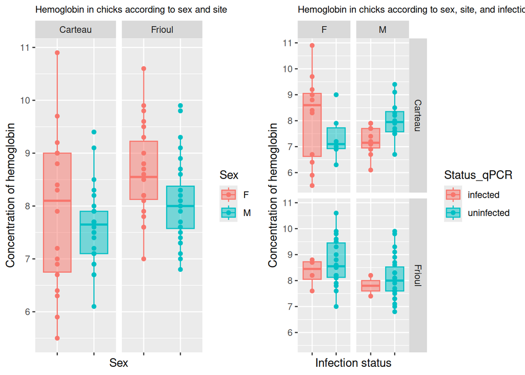

```r
plotC <- ggplot(data_hemo_ch_model, aes(x= Sex, y= Hemoglobin, color=Sex, fill=Sex))+
  geom_point() +
  geom_boxplot(alpha=0.5) +
  labs(x = "Sex",
       y = "Concentration of hemoglobin",
       title = "Hemoglobin in chicks according to sex and site") +
  theme(axis.text.x = element_blank(),
        plot.title = element_text(size = 9)) +
  facet_grid(~Site)

plotD <- ggplot(data_hemo_ch_model, aes(x= Status_qPCR, y= Hemoglobin, color=Status_qPCR, fill=Status_qPCR))+
  geom_point() +
  geom_boxplot(alpha=0.5) +
  labs(x = "Infection status",
       y = "Concentration of hemoglobin",
       title = "Hemoglobin in chicks according to sex, site, and infection status") +
  theme(axis.text.x = element_blank(),
        plot.title = element_text(size = 9)) +
  facet_grid(Site~Sex)

ggarrange(plotC, plotD, nrow = 1, ncol = 2)
```

## 2.2. Based on parasitemia (continuous)

### 2.2.1. In adults

To determine whether a Pearson Correlation test can be used, the data must be tested for normality, autocorrelation and homoscedasticity:

```r
shapiro.test(data_hemo_ad_ratioBab$Hemoglobin)
```

```
##
##  Shapiro-Wilk normality test
##
## data:  data_hemo_ad_ratioBab$Hemoglobin
## W = 0.87962, p-value = 0.1292
```

**p-value > 0.05, the data is normally distributed.**

```r
bptest(aov(Hemoglobin ~ Ratio_qPCR, data = data_hemo_ad_ratioBab))
```

```
##
##  studentized Breusch-Pagan test
##
## data:  aov(Hemoglobin ~ Ratio_qPCR, data = data_hemo_ad_ratioBab)
## BP = 0.52736, df = 1, p-value = 0.4677
```

**p-value > 0.05, the null hypothesis of residual homoscedasticity cannot be rejected.**

```r
dwtest(aov(Hemoglobin ~ Ratio_qPCR, data = data_hemo_ad_ratioBab))
```

```
##
##  Durbin-Watson test
##
## data:  aov(Hemoglobin ~ Ratio_qPCR, data = data_hemo_ad_ratioBab)
## DW = 2.8499, p-value = 0.925
## alternative hypothesis: true autocorrelation is greater than 0
```

**p-value > 0.05, the null hypothesis that the residuals are not autocorrelated cannot be rejected.**

We can use a Pearson Correlation test:

```r
hemo_adults <- data_hemo_ad_ratioBab$Hemoglobin
ratioqPCR_adults <- data_hemo_ad_ratioBab$Ratio_qPCR
cor.test(hemo_adults,ratioqPCR_adults, method="pearson")
```

```
##
##  Pearson's product-moment correlation
##
## data:  hemo_adults and ratioqPCR_adults
## t = 0.92477, df = 8, p-value = 0.3821
## alternative hypothesis: true correlation is not equal to 0
## 95 percent confidence interval:
##  -0.3964268  0.7865011
## sample estimates:
##       cor
## 0.3107673
```

**p-value > 0.05 (p-value = 0.3821 & cor = 0.3107673), the null hypothesis that there is no correlation between the two variables `Hemoglobin` and `Ratio_qPCR` cannot be rejected.**

**The parasitemia doesn’t influence the circulating concentration of hemoglobin in adults.**

### 2.2.2. In chicks

We include the variables `Ratio_qPCR`, `Ticks_by_nest` and `SMI` as fixed effects and `Site`, `Sex`, and `Year` as random effects in our full LMER model. We will analyse `Ratio_qPCR` using a log-transformation:

```r
data_hemo_ch_ratioBab$log_ratio_qPCR <- log10(data_hemo_ch_ratioBab$Ratio_qPCR)

lmer_hemo_ch_ratio_full <- lmer(Hemoglobin ~ log_ratio_qPCR * SMI * Ticks_by_nest + (1|Site) + (1|Sex) + (1|Year), data=data_hemo_ch_ratioBab, na.action = na.fail)
```

We use the dredge function to compare models:

```r
model_dredge_hemo_ratio_ch <- dredge(lmer_hemo_ch_ratio_full)
model_dredge_hemo_ratio_ch
```

```
## Global model call: lmer(formula = Hemoglobin ~ log_ratio_qPCR * SMI * Ticks_by_nest +
##     (1 | Site) + (1 | Sex) + (1 | Year), data = data_hemo_ch_ratioBab,
##     na.action = na.fail)
## ---
## Model selection table
##       (Int) log_rat_qPC        SMI Tck_by_nst log_rat_qPC:SMI
## 1    7.7350
## 2    7.1090   -0.110600
## 5    7.7590                        -0.0041750
## 3   10.1000             -0.0032540
## 6    7.0560   -0.116900             0.0023420
## 4    9.6350   -0.055280 -0.0030120
## 7   10.1400             -0.0032990 -0.0005898
## 22   7.4520   -0.032830            -0.0364000
## 8    9.6100   -0.060090 -0.0030450  0.0020190
```

[output cut: 53 more lines]

Based on these results, the model with the lower AICc is `1 + (1|Site) + (1|Sex) + (1|Year)`.  
To validate it, we will also compare it with the model with `log_ratio_qPCR`:

```r
lmer_hemo_ch_ratio_null <- lmer(Hemoglobin ~ 1 + (1|Site) + (1|Sex) + (1|Year), data=data_hemo_ch_ratioBab, na.action = na.fail)
lmer_hemo_ch_ratio_1 <- lmer(Hemoglobin ~ log_ratio_qPCR + (1|Site) + (1|Sex) + (1|Year), data=data_hemo_ch_ratioBab, na.action = na.fail)

anova(lmer_hemo_ch_ratio_null, lmer_hemo_ch_ratio_1, test="Chisq")
```

```
## Data: data_hemo_ch_ratioBab
## Models:
## lmer_hemo_ch_ratio_null: Hemoglobin ~ 1 + (1 | Site) + (1 | Sex) + (1 | Year)
## lmer_hemo_ch_ratio_1: Hemoglobin ~ log_ratio_qPCR + (1 | Site) + (1 | Sex) + (1 | Year)
##                         npar    AIC    BIC  logLik -2*log(L) Chisq Df
## lmer_hemo_ch_ratio_null    5 81.207 87.301 -35.604    71.207
## lmer_hemo_ch_ratio_1       6 81.998 89.311 -34.999    69.998 1.209  1
##                         Pr(>Chisq)
## lmer_hemo_ch_ratio_null
## lmer_hemo_ch_ratio_1        0.2715
```

We examine the models (NB: DHARMA cannot be used on weighted LMER):

```r
tab_model(lmer_hemo_ch_ratio_null, lmer_hemo_ch_ratio_1, string.est = "IRR", show.aicc = TRUE, digits=2, show.ci = FALSE, show.intercept = FALSE)
```

|  | Hemoglobin |  | Hemoglobin |  |
| --- | --- | --- | --- | --- |
| Predictors | IRR | p | IRR | p |
| log ratio qPCR |  |  | -0.11 | 0.278 |
| Random Effects |  |  |  |  |
| σ<sup>2</sup> | 0.94 |  | 0.94 |  |
| τ<sub>00</sub> | 0.00 <sub>Year</sub> |  | 0.00 <sub>Year</sub> |  |
|  | 0.21 <sub>Sex</sub> |  | 0.26 <sub>Sex</sub> |  |
|  | 0.05 <sub>Site</sub> |  | 0.00 <sub>Site</sub> |  |
| N | 2 <sub>Site</sub> |  | 2 <sub>Site</sub> |  |
|  | 2 <sub>Sex</sub> |  | 2 <sub>Sex</sub> |  |
|  | 3 <sub>Year</sub> |  | 3 <sub>Year</sub> |  |
| Observations | 25 |  | 25 |  |
| Marginal R<sup>2</sup> / Conditional R<sup>2</sup> | 0.000 / NA |  | 0.050 / NA |  |
| AICc | 84.711 |  | 89.821 |  |

We choose the model `1 + (1|Site) + (1|Sex) + (1|Year)` as the best-fitted model.  
We examine the best-fitted model:

```r
summary(lmer_hemo_ch_ratio_null)
```

```
## Linear mixed model fit by REML ['lmerMod']
## Formula: Hemoglobin ~ 1 + (1 | Site) + (1 | Sex) + (1 | Year)
##    Data: data_hemo_ch_ratioBab
##
## REML criterion at convergence: 71.6
##
## Scaled residuals:
##     Min      1Q  Median      3Q     Max
## -2.4947 -0.4896  0.1088  0.6239  1.8324
##
## Random effects:
##  Groups   Name        Variance Std.Dev.
##  Year     (Intercept) 0.00000  0.0000
##  Sex      (Intercept) 0.20570  0.4535
##  Site     (Intercept) 0.05174  0.2275
##  Residual             0.94214  0.9706
## Number of obs: 25, groups:  Year, 3; Sex, 2; Site, 2
##
## Fixed effects:
##             Estimate Std. Error t value
## (Intercept)   7.7348     0.4158    18.6
## optimizer (nloptwrap) convergence code: 0 (OK)
## boundary (singular) fit: see help('isSingular')
```

```r
shapiro.test(residuals(lmer_hemo_ch_ratio_null))
```

```
##
##  Shapiro-Wilk normality test
##
## data:  residuals(lmer_hemo_ch_ratio_null)
## W = 0.97175, p-value = 0.6897
```

**Conclusion:**

**Based on the measured variables, we did not identified a fixed effect influencing the circulating concentration of hemoglobin in chicks, including the parasitemia of *Babesia*.**

Visualisation:

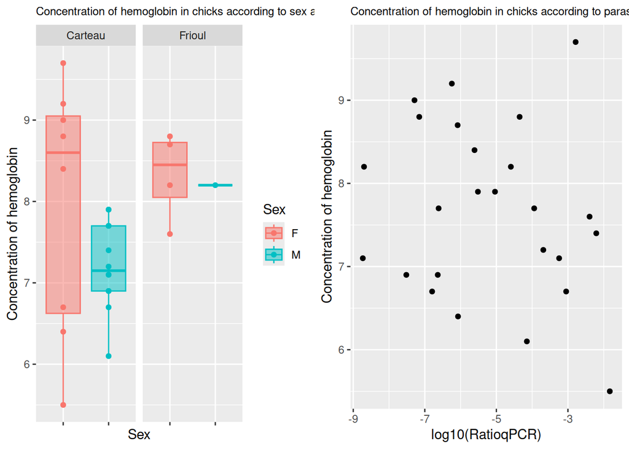

```r
plotE <- ggplot(data_hemo_ch_ratioBab, aes(x= Sex, y= Hemoglobin, color=Sex, fill=Sex)) +
  geom_point() +
  geom_boxplot(alpha=0.5) +
  labs(x = "Sex",
       y = "Concentration of hemoglobin",
       title = "Concentration of hemoglobin in chicks according to sex and site") +
  theme(axis.text.x = element_blank(),
        plot.title = element_text(size = 9)) +
  facet_grid(~Site)

plotF <- ggplot(data_hemo_ch_ratioBab, aes(x = log_ratio_qPCR, y = Hemoglobin)) +
  geom_point() +
  labs(x = "log10(RatioqPCR)",
       y = "Concentration of hemoglobin",
       title = "Concentration of hemoglobin in chicks according to parasitemia") +
  theme(plot.title = element_text(size = 9))

ggarrange(plotE, plotF, nrow = 1, ncol = 2)
```

# 3. Effects of infection on body condition

## 3.1. Based on infectious status (binary: infected/uninfected)

### 3.1.1. In adults

We include the variables `Status_qPCR` and `Ticks_by_nest` as a fixed effect and `Site`, `Sex`, and `Year` as random effects in our full LMER model:

```r
lmer_smi_ad_full <- lmer(SMI ~ Status_qPCR * Ticks_by_nest + (1|Site) + (1|Sex) + (1|Year), data=data_smi_ad_model, na.action = na.fail)
```

We use the dredge function to compare models:

```r
model_dredge_smi_ad <- dredge(lmer_smi_ad_full)
model_dredge_smi_ad
```

```
## Global model call: lmer(formula = SMI ~ Status_qPCR * Ticks_by_nest + (1 | Site) +
##     (1 | Sex) + (1 | Year), data = data_smi_ad_model, na.action = na.fail)
## ---
## Model selection table
##    (Int) Stt_qPC Tck_by_nst Stt_qPC:Tck_by_nst df   logLik   AICc delta weight
## 8  978.3       +     1.3760                  +  8 -571.669 1161.0  0.00  0.484
## 2  997.2       +                                6 -574.435 1161.8  0.84  0.319
## 4  993.3       +     0.2939                     7 -573.780 1162.8  1.85  0.192
## 1 1046.0                                        5 -580.210 1171.1 10.12  0.003
## 3 1045.0             0.1098                     6 -579.621 1172.2 11.21  0.002
## Models ranked by AICc(x)
## Random terms (all models):
##   1 | Site, 1 | Sex, 1 | Year
```

Based on `model_dredge_smi_ad`, the model with the minimal AICc value is `Status_qPCR * Ticks_by_nest + (1|Site) + (1|Sex) + (1|Year)`.  
To validate it as the best-fitted model, we compare it with all models having an AICc difference of 2 or less:

```r
lmer_smi_ad_1 <- lmer(SMI ~ Status_qPCR + (1|Site) + (1|Sex) + (1|Year), data=data_smi_ad_model, na.action = na.fail)
lmer_smi_ad_2 <- lmer(SMI ~ Status_qPCR + Ticks_by_nest + (1|Site) + (1|Sex) + (1|Year), data=data_smi_ad_model, na.action = na.fail)

anova3 <- anova(lmer_smi_ad_full, lmer_smi_ad_1, test="Chisq")
anova4 <- anova(lmer_smi_ad_full, lmer_smi_ad_2, test="Chisq")

p_value_anova3 <- anova3$`Pr(>Chisq)`[2]
p_value_anova4 <- anova4$`Pr(>Chisq)`[2]

anova_results_smi_ad <- data.frame(
  Comparison = c("full (best)",
                 "best vs Status_qPCR",
                 "best vs Status_qPCR + Ticks_by_nest"),
  ANOVA_p_value = c("-", p_value_anova3, p_value_anova4),
  AICc = c(AICc(lmer_smi_ad_full), AICc(lmer_smi_ad_1), AICc(lmer_smi_ad_2)))

# Print the table with kable
anova_results_smi_ad %>%
  kable(caption = "Results of comparison between best AICc model and other models") %>%
  kable_styling(bootstrap_options = c("striped", "hover", "condensed", "responsive"))
```

Results of comparison between best AICc model and other models

Comparison

ANOVA_p_value

AICc

full (best)

1160.956

best vs Status_qPCR

0.90422027625422

1161.793

best vs Status_qPCR + Ticks_by_nest

0.739636762851984

1162.805

We can also compare them with `tab_model` function:

```r
tab_model(lmer_smi_ad_full, lmer_smi_ad_1, lmer_smi_ad_2, string.est = "IRR", show.aicc = TRUE, digits=2, show.ci = FALSE, show.intercept = FALSE)
```

|  | SMI |  | SMI |  | SMI |  |
| --- | --- | --- | --- | --- | --- | --- |
| Predictors | IRR | p | IRR | p | IRR | p |
| Status qPCR [uninfected] | 71.16 | 0.185 | 53.97 | 0.099 | 55.75 | 0.092 |
| Ticks by nest | 1.38 | 0.649 |  |  | 0.29 | 0.685 |
| Status qPCR [uninfected] × Ticks by nest | -1.13 | 0.714 |  |  |  |  |
| Random Effects |  |  |  |  |  |  |
| σ<sup>2</sup> | 8697.20 |  | 8583.01 |  | 8624.10 |  |
| τ<sub>00</sub> | 115.10 <sub>Year</sub> |  | 31.28 <sub>Year</sub> |  | 100.45 <sub>Year</sub> |  |
|  | 0.00 <sub>Sex</sub> |  | 0.00 <sub>Sex</sub> |  | 0.00 <sub>Sex</sub> |  |
|  | 0.00 <sub>Site</sub> |  | 0.00 <sub>Site</sub> |  | 0.00 <sub>Site</sub> |  |
| ICC | 0.01 |  |  |  |  |  |
| N | 2 <sub>Site</sub> |  | 2 <sub>Site</sub> |  | 2 <sub>Site</sub> |  |
|  | 2 <sub>Sex</sub> |  | 2 <sub>Sex</sub> |  | 2 <sub>Sex</sub> |  |
|  | 3 <sub>Year</sub> |  | 3 <sub>Year</sub> |  | 3 <sub>Year</sub> |  |
| Observations | 98 |  | 98 |  | 98 |  |
| Marginal R<sup>2</sup> / Conditional R<sup>2</sup> | 0.030 / 0.043 |  | 0.028 / NA |  | 0.029 / NA |  |
| AICc | 1160.956 |  | 1161.793 |  | 1162.805 |  |

Based on these results:  
- The AICc of the model including `Status_qPCR * Ticks_by_nest` is lower than the others  
- In the full model, the p of `Status_qPCR` equals 0.185 which is close but greater than 0.05  
- In the model with `Status_qPCR` alone, the p of `Status_qPCR` equals 0.099 which is close but greater than 0.05.

Based on these results, we select `Status_qPCR * Ticks_by_nest + (1|Site) + (1|Sex) + (1|Year)` as the best-fitted model.

We examine the best-fitted model:

```r
summary(lmer_smi_ad_full)
```

```
## Linear mixed model fit by REML ['lmerMod']
## Formula: SMI ~ Status_qPCR * Ticks_by_nest + (1 | Site) + (1 | Sex) +
##     (1 | Year)
##    Data: data_smi_ad_model
##
## REML criterion at convergence: 1143.3
##
## Scaled residuals:
##     Min      1Q  Median      3Q     Max
## -2.8101 -0.4928  0.0010  0.5302  3.7019
##
## Random effects:
##  Groups   Name        Variance  Std.Dev.
##  Year     (Intercept) 1.151e+02 10.728403
##  Sex      (Intercept) 3.740e-06  0.001934
##  Site     (Intercept) 1.103e-06  0.001050
##  Residual             8.697e+03 93.258755
## Number of obs: 98, groups:  Year, 3; Sex, 2; Site, 2
##
## Fixed effects:
##                                     Estimate Std. Error t value
## (Intercept)                          978.281     52.426  18.660
## Status_qPCRuninfected                 71.156     53.236   1.337
## Ticks_by_nest                          1.376      3.013   0.457
## Status_qPCRuninfected:Ticks_by_nest   -1.133      3.088  -0.367
##
## Correlation of Fixed Effects:
##             (Intr) St_PCR Tcks__
## Stts_qPCRnn -0.970
## Tcks_by_nst -0.796  0.782
## Stt_PCR:T__  0.774 -0.786 -0.970
## optimizer (nloptwrap) convergence code: 0 (OK)
## boundary (singular) fit: see help('isSingular')
```

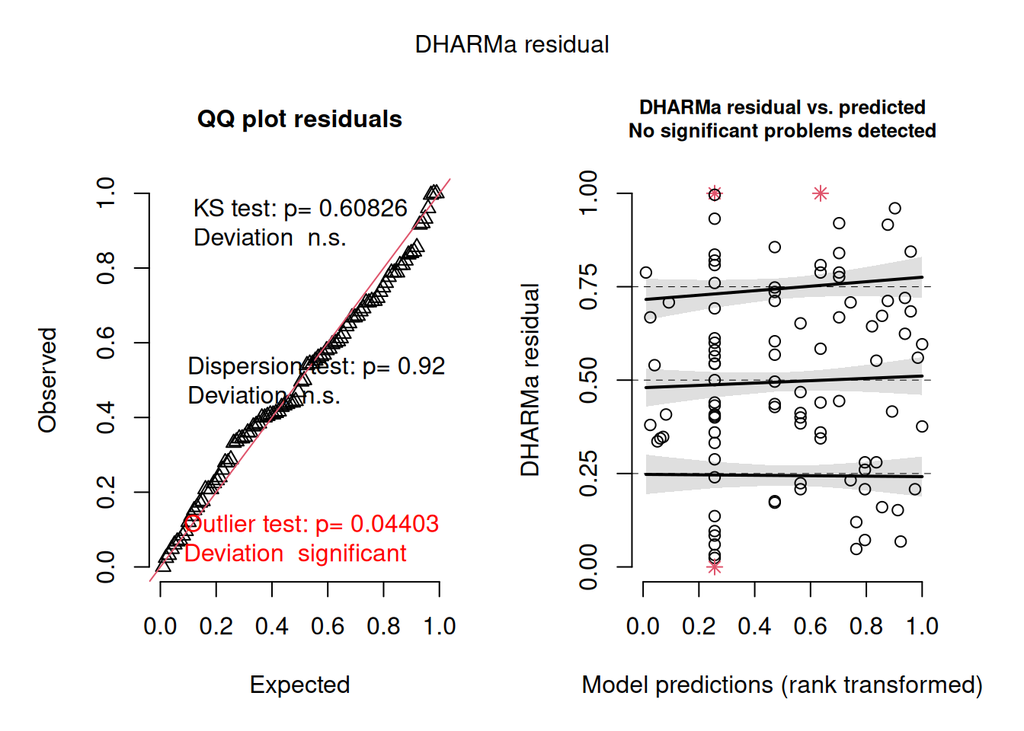

```r
simulationOutput_smi_ad <- simulateResiduals(fittedModel = lmer_smi_ad_full, plot = F)
plot(simulationOutput_smi_ad)
```

```r
shapiro.test(residuals(lmer_smi_ad_full))
```

```
##
##  Shapiro-Wilk normality test
##
## data:  residuals(lmer_smi_ad_full)
## W = 0.94699, p-value = 0.0006101
```

**Conclusion:**  
**Adding `Status_qPCR` and `Ticks_by_nest` improved model fit and the estimated effect of `Status_qPCR` shows a possible trend (p ≈ 0.1), but evidence is not strong enough in the current dataset. There may be an effect of the presence of *Babesia* on the SMI in adults, but current data don’t provide strong evidence.**

Visualisation:

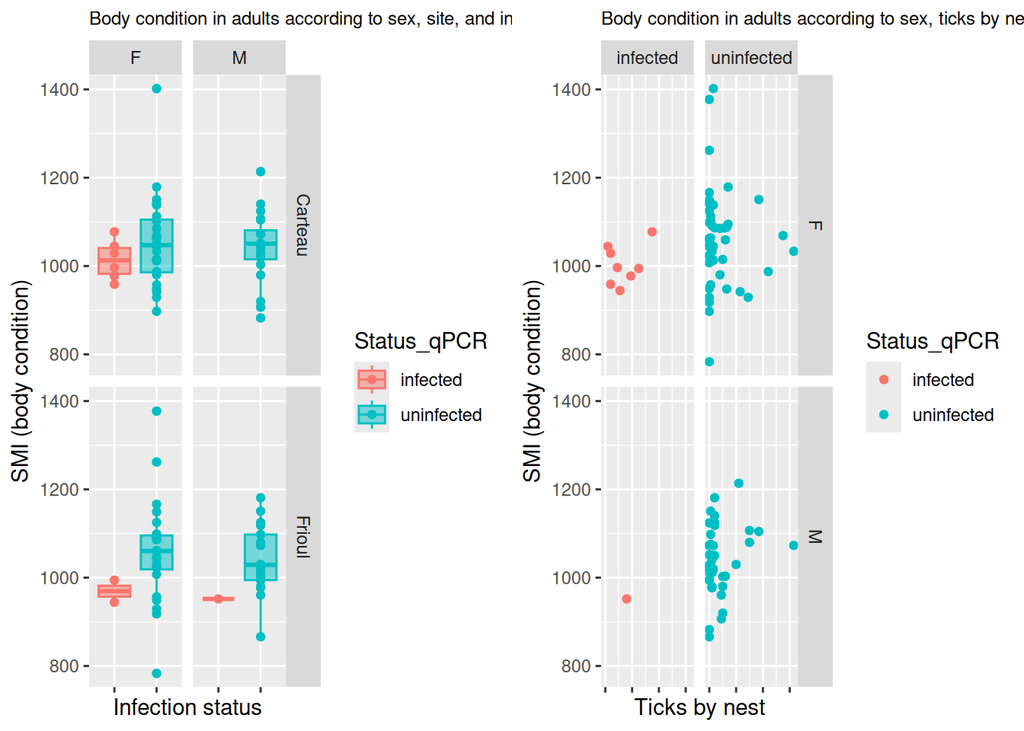

```r
plotG <- ggplot(data_smi_ad_model, aes(x= Status_qPCR, y= SMI, color=Status_qPCR, fill=Status_qPCR))+
  geom_point() +
  geom_boxplot(alpha=0.5) +
  labs(x = "Infection status",
       y = "SMI (body condition)",
       title = "Body condition in adults according to sex, site, and infection status")+
  theme(plot.title = element_text(size = 9),
        axis.text.x = element_blank()) +
  facet_grid(Site~Sex)

plotH <- ggplot(data_smi_ad_model, aes(x= Ticks_by_nest, y= SMI, color=Status_qPCR, fill=Status_qPCR))+
  geom_point() +
  labs(x = "Ticks by nest",
       y = "SMI (body condition)",
       title = "Body condition in adults according to sex, ticks by nest, and infection status")+
  theme(plot.title = element_text(size = 9),
        axis.text.x = element_blank()) +
  facet_grid(Sex~Status_qPCR)

ggarrange(plotG, plotH, nrow = 1, ncol = 2)
```

### 3.1.2. In chicks

We include the variables `Status_qPCR` and `Ticks_by_nest` as a fixed effect and `Site`, `Sex`, and `Year` as random effects in our full LMER model:

```r
lmer_smi_ch_full <- lmer(log_smi ~ Status_qPCR * Ticks_by_nest + (1|Site) + (1|Sex) + (1|Year), data=data_smi_ch_model, na.action = na.fail)
```

We use the dredge function to compare models:

```r
model_dredge_smi_ch <- dredge(lmer_smi_ch_full)
model_dredge_smi_ch
```

```
## Global model call: lmer(formula = log_smi ~ Status_qPCR * Ticks_by_nest + (1 | Site) +
##     (1 | Sex) + (1 | Year), data = data_smi_ch_model, na.action = na.fail)
## ---
## Model selection table
##   (Int) Stt_qPC Tck_by_nst Stt_qPC:Tck_by_nst df  logLik   AICc delta weight
## 1 2.866                                        5 136.237 -261.8  0.00  0.982
## 2 2.858       +                                6 133.337 -253.7  8.08  0.017
## 3 2.864          0.0003520                     6 129.837 -246.7 15.08  0.001
## 4 2.853       +  0.0005249                     7 127.134 -239.0 22.83  0.000
## 8 2.853       +  0.0004849                  +  8 121.417 -225.1 36.65  0.000
## Models ranked by AICc(x)
## Random terms (all models):
##   1 | Site, 1 | Sex, 1 | Year
```

Based on `model_dredge_smi_ch`, the model with the minimal AICc value is `1 + (1|Site) + (1|Sex) + (1|Year)`.  
To validate it as the best-fitted model, we compare it with the model with `Status_qPCR`:

```r
lmer_smi_ch_null <- lmer(log_smi ~ 1 + (1|Site) + (1|Sex) + (1|Year), data=data_smi_ch_model, na.action = na.fail)
lmer_smi_ch_1 <- lmer(log_smi ~ Status_qPCR + (1|Site) + (1|Sex) + (1|Year), data=data_smi_ch_model, na.action = na.fail)

anova5 <- anova(lmer_smi_ch_null, lmer_smi_ch_1, test="Chisq")

p_value_anova5 <- anova5$`Pr(>Chisq)`[2]

anova_results_smi_ch <- data.frame(
  Comparison = c("null (best)",
                 "best vs Status_qPCR"),
  ANOVA_p_value = c("-", p_value_anova5),
  AICc = c(AICc(lmer_smi_ch_null), AICc(lmer_smi_ch_1)))

# Print the table with kable
anova_results_smi_ch %>%
  kable(caption = "Results of comparison between best AICc model and other models") %>%
  kable_styling(bootstrap_options = c("striped", "hover", "condensed", "responsive"))
```

Results of comparison between best AICc model and other models

Comparison

ANOVA_p_value

AICc

null (best)

-261.7931

best vs Status_qPCR

0.382069972086064

-253.7084

We can also compare them with `tab_model` function:

```r
tab_model(lmer_smi_ch_null, lmer_smi_ch_1, string.est = "IRR", show.aicc = TRUE, digits=2, show.ci = FALSE, show.intercept = FALSE)
```

|  | log_smi |  | log_smi |  |
| --- | --- | --- | --- | --- |
| Predictors | IRR | p | IRR | p |
| Status qPCR [uninfected] |  |  | 0.01 | 0.310 |
| Random Effects |  |  |  |  |
| σ<sup>2</sup> | 0.00 |  | 0.00 |  |
| τ<sub>00</sub> | 0.00 <sub>Year</sub> |  | 0.00 <sub>Year</sub> |  |
|  | 0.00 <sub>Sex</sub> |  | 0.00 <sub>Sex</sub> |  |
|  | 0.00 <sub>Site</sub> |  | 0.00 <sub>Site</sub> |  |
| ICC | 0.30 |  | 0.36 |  |
| N | 2 <sub>Site</sub> |  | 2 <sub>Site</sub> |  |
|  | 2 <sub>Sex</sub> |  | 2 <sub>Sex</sub> |  |
|  | 3 <sub>Year</sub> |  | 3 <sub>Year</sub> |  |
| Observations | 94 |  | 94 |  |
| Marginal R<sup>2</sup> / Conditional R<sup>2</sup> | 0.000 / 0.302 |  | 0.009 / 0.369 |  |
| AICc | -261.793 |  | -253.708 |  |

Based on these results, we select `1 + (1|Site) + (1|Sex) + (1|Year)` as the best-fitted model.

```r
shapiro.test(residuals(lmer_smi_ch_null))
```

```
##
##  Shapiro-Wilk normality test
##
## data:  residuals(lmer_smi_ch_null)
## W = 0.97444, p-value = 0.0621
```

**Based on the measured variables, we did not identified a fixed effect influencing the body condition in chicks, including the presence of *Babesia*.**

Visualisation:

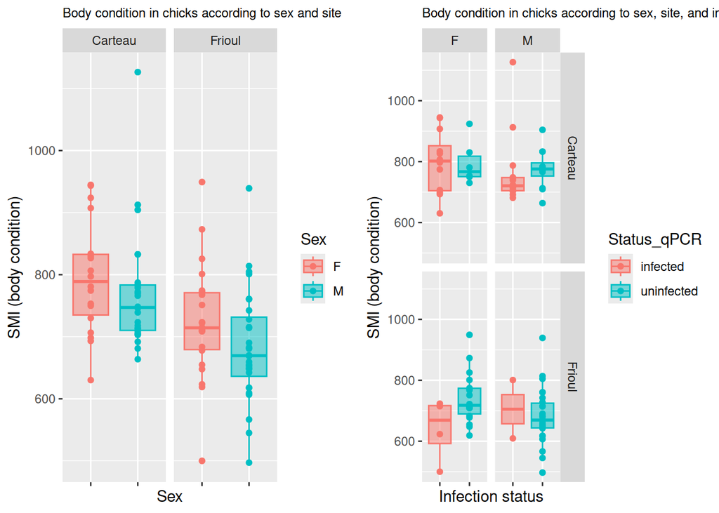

```r
plotI <- ggplot(data_smi_ch_model, aes(x= Sex, y= SMI, color=Sex, fill=Sex))+
  geom_point() +
  geom_boxplot(alpha=0.5) +
  labs(x = "Sex",
       y = "SMI (body condition)",
       title = "Body condition in chicks according to sex and site")+
  theme(plot.title = element_text(size = 9),
        axis.text.x = element_blank()) +
  facet_grid(~Site)

plotJ <- ggplot(data_smi_ch_model, aes(x= Status_qPCR, y= SMI, color=Status_qPCR, fill=Status_qPCR))+
  geom_point() +
  geom_boxplot(alpha=0.5) +
  labs(x = "Infection status",
       y = "SMI (body condition)",
       title = "Body condition in chicks according to sex, site, and infection status")+
  theme(plot.title = element_text(size = 9),
        axis.text.x = element_blank()) +
  facet_grid(Site~Sex)

ggarrange(plotI, plotJ, nrow = 1, ncol = 2)
```

## 3.2. Based on parasitemia (continuous)

### 3.2.1. In adults

To determine whether a Pearson Correlation test can be used, the data must be tested for normality, autocorrelation and homoscedasticity:

```r
shapiro.test(data_smi_ad_ratioBab$SMI)
```

```
##
##  Shapiro-Wilk normality test
##
## data:  data_smi_ad_ratioBab$SMI
## W = 0.93891, p-value = 0.541
```

**p-value > 0.05, the data is normally distributed.**

```r
bptest(aov(SMI ~ Ratio_qPCR, data = data_smi_ad_ratioBab))
```

```
##
##  studentized Breusch-Pagan test
##
## data:  aov(SMI ~ Ratio_qPCR, data = data_smi_ad_ratioBab)
## BP = 0.065109, df = 1, p-value = 0.7986
```

**p-value > 0.05, the null hypothesis of residual homoscedasticity cannot be rejected.**

```r
dwtest(aov(SMI ~ Ratio_qPCR, data = data_smi_ad_ratioBab))
```

```
##
##  Durbin-Watson test
##
## data:  aov(SMI ~ Ratio_qPCR, data = data_smi_ad_ratioBab)
## DW = 2.7415, p-value = 0.8923
## alternative hypothesis: true autocorrelation is greater than 0
```

**p-value > 0.05, the null hypothesis that the residuals are not autocorrelated cannot be rejected.**

We can use a Pearson Correlation test:

```r
smi_adults <- data_smi_ad_ratioBab$SMI
ratioqPCR_adults <- data_smi_ad_ratioBab$Ratio_qPCR
cor.test(smi_adults,ratioqPCR_adults, method="pearson")
```

```
##
##  Pearson's product-moment correlation
##
## data:  smi_adults and ratioqPCR_adults
## t = -0.37908, df = 8, p-value = 0.7145
## alternative hypothesis: true correlation is not equal to 0
## 95 percent confidence interval:
##  -0.7036143  0.5421323
## sample estimates:
##        cor
## -0.1328364
```

**p-value > 0.05 (p-value = 0.7145 & cor = -0.1328364), the null hypothesis that there is no correlation between the two variables `SMI` and `Ratio_qPCR` cannot be rejected.**  
**The parasitemia doesn’t influence the body condition in adults.**

### 3.2.2. In chicks

We include the variables `Ratio_qPCR` and `Ticks_by_nest` as a fixed effect and `Site`, `Sex`, and `Year` as random effects in our full LMER model.

```r
data_smi_ch_ratioBab$log_ratio_qPCR <- log10(data_smi_ch_ratioBab$Ratio_qPCR)
lmer_smi_ch_ratio_full <- lmer(log_smi ~ log_ratio_qPCR * Ticks_by_nest + (1|Site) + (1|Sex) + (1|Year), data=data_smi_ch_ratioBab, na.action = na.fail)
```

We use the dredge function to compare models:

```r
model_dredge_smi_ratio_ch <- dredge(lmer_smi_ch_ratio_full)
model_dredge_smi_ratio_ch
```

```
## Global model call: lmer(formula = log_smi ~ log_ratio_qPCR * Ticks_by_nest + (1 |
##     Site) + (1 | Sex) + (1 | Year), data = data_smi_ch_ratioBab,
##     na.action = na.fail)
## ---
## Model selection table
##   (Int) log_rat_qPC Tck_by_nst log_rat_qPC:Tck_by_nst df logLik  AICc delta
## 1 2.845                                                5 30.480 -47.8  0.00
## 2 2.896    0.009623                                    6 27.354 -38.0  9.76
## 3 2.842              0.0002803                         6 24.375 -32.1 15.72
## 4 2.900    0.010060 -0.0001301                         7 21.317 -22.0 25.76
## 8 2.879    0.004729  0.0019700              0.0005888  8 15.253  -5.5 42.30
##   weight
## 1  0.992
## 2  0.008
## 3  0.000
## 4  0.000
## 8  0.000
## Models ranked by AICc(x)
## Random terms (all models):
##   1 | Site, 1 | Sex, 1 | Year
```

Based on `model_dredge_smi_ch`, the model with the minimal AICc value is `1 + (1|Site) + (1|Sex) + (1|Year)`.  
To validate it as the best-fitted model, we compare it with the model with `log_ratio_qPCR`:

```r
lmer_smi_ch_ratio_null <- lmer(log_smi ~ 1 + (1|Site) + (1|Sex) + (1|Year), data=data_smi_ch_ratioBab, na.action = na.fail)
lmer_smi_ch_ratio_1 <- lmer(log_smi ~ log_ratio_qPCR + (1|Site) + (1|Sex) + (1|Year), data=data_smi_ch_ratioBab, na.action = na.fail)

anova6 <- anova(lmer_smi_ch_ratio_null, lmer_smi_ch_ratio_1, test="Chisq")

p_value_anova6 <- anova6$`Pr(>Chisq)`[2]

anova_results_smi_ratio_ch <- data.frame(
  Comparison = c("null (best)",
                 "best vs log_ratio_qPCR"),
  ANOVA_p_value = c("-", p_value_anova6),
  AICc = c(AICc(lmer_smi_ch_ratio_null), AICc(lmer_smi_ch_ratio_1)))

# Print the table with kable
anova_results_smi_ratio_ch %>%
  kable(caption = "Results of comparison between best AICc model and other models") %>%
  kable_styling(bootstrap_options = c("striped", "hover", "condensed", "responsive"))
```

Results of comparison between best AICc model and other models

Comparison

ANOVA_p_value

AICc

null (best)

-47.80243

best vs log_ratio_qPCR

0.141390785095493

-38.04217

We can also compare them with `tab_model` function:

```r
tab_model(lmer_smi_ch_ratio_null, lmer_smi_ch_ratio_1, string.est = "IRR", show.aicc = TRUE, digits=2, show.ci = FALSE, show.intercept = FALSE)
```

|  | log_smi |  | log_smi |  |
| --- | --- | --- | --- | --- |
| Predictors | IRR | p | IRR | p |
| log ratio qPCR |  |  | 0.01 | 0.152 |
| Random Effects |  |  |  |  |
| σ<sup>2</sup> | 0.00 |  | 0.00 |  |
| τ<sub>00</sub> | 0.00 <sub>Year</sub> |  | 0.00 <sub>Year</sub> |  |
|  | 0.00 <sub>Sex</sub> |  | 0.00 <sub>Sex</sub> |  |
|  | 0.00 <sub>Site</sub> |  | 0.00 <sub>Site</sub> |  |
| N | 2 <sub>Site</sub> |  | 2 <sub>Site</sub> |  |
|  | 2 <sub>Sex</sub> |  | 2 <sub>Sex</sub> |  |
|  | 3 <sub>Year</sub> |  | 3 <sub>Year</sub> |  |
| Observations | 25 |  | 25 |  |
| Marginal R<sup>2</sup> / Conditional R<sup>2</sup> | 0.000 / NA |  | 0.097 / NA |  |
| AICc | -47.802 |  | -38.042 |  |

Based on these results, the model with the lower AICc is `1 + (1|Site) + (1|Sex) + (1|Year)`.

```r
shapiro.test(residuals(lmer_smi_ch_ratio_null))
```

```
##
##  Shapiro-Wilk normality test
##
## data:  residuals(lmer_smi_ch_ratio_null)
## W = 0.92255, p-value = 0.05859
```

**Based on the measured variables, we did not identified a fixed effect influencing the body condition in chucks, including the parasitemia.**

Visualisation:

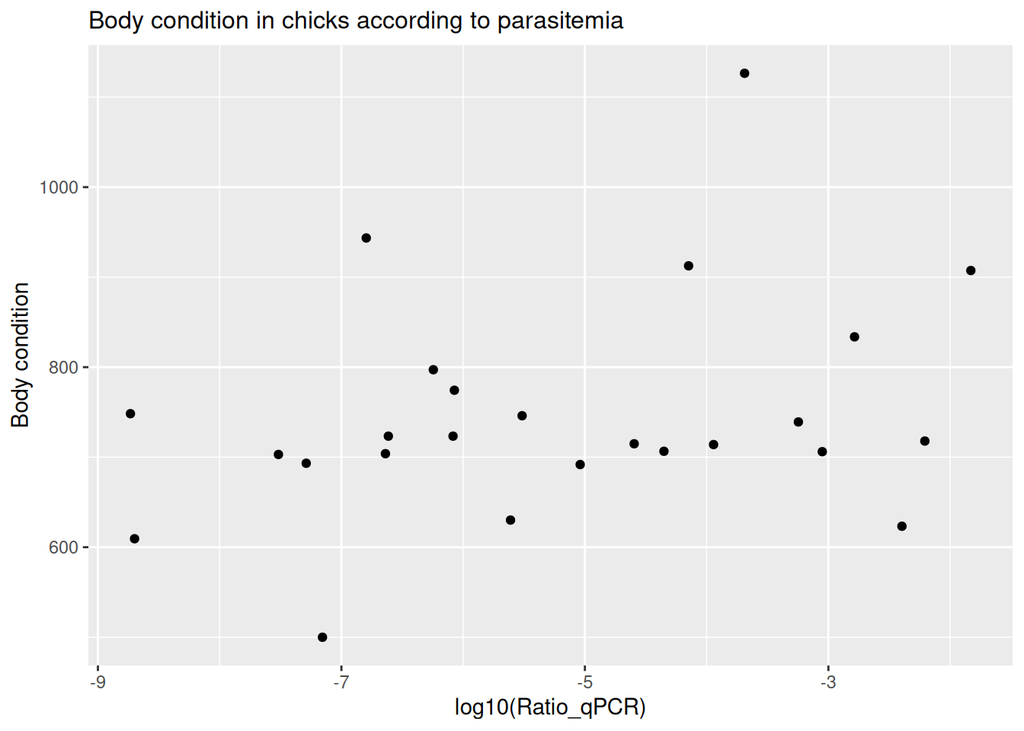

```r
ggplot(data_smi_ch_ratioBab, aes(x = log_ratio_qPCR, y = SMI)) +
  geom_point() +
  labs(x = "log10(Ratio_qPCR)",
       y = "Body condition",
       title = "Body condition in chicks according to parasitemia") +
  theme(plot.title = element_text(size = 12))
```

# 4. Summary

## 4.1. Circulating Hemoglobin Concentration

In adults, *Babesia* infection status does not affect hemoglobin concentration (LMER best-fitted model: `1 + (1|Site) + (1|Sex) + (1|Year)`), nor does parasitemia (Pearson correlation, p = 0.3821).

In chicks, *Babesia* infection status does not affect hemoglobin concentration (LMER best-fitted model: `1 + (1|Site) + (1|Sex) + (1|Year)`), nor does parasitemia (LMER best-fitted model: `1 + (1|Site) + (1|Sex) + (1|Year)`).

## 4.2. Body Condition

In adults, *Babesia* infection status and tick burden show a possible trend on Scaled Mass Index (LMER best-fitted model: `Status_qPCR * Ticks_by_nest + (1|Site) + (1|Sex) + (1|Year)`) but this trend needs to be examined with more data. However, the parasitemia does not affect Scaled Mass Index (Pearson correlation, p = 0.7145).

In chicks, *Babesia* infection status does not affect body condition (LMER best-fitted model: `1 + (1|Site) + (1|Sex) + (1|Year)`), nor does the parasitemia (LMER best-fitted model: `1 + (1|Site) + (1|Sex) + (1|Year)`).